# An R Markdown document converted from “C://Users//nzoro//OneDrive//Documents//Esilv//Actuariat//R_Cours//apercu_Projet_R.ipynb”

[figure not shown]

[figure not shown]

[figure not shown]

[figure not shown]

[figure not shown]

[figure not shown]

[figure not shown]

[figure not shown]

[figure not shown]

[figure not shown]

[figure not shown]

[figure not shown]

[13 more figures not shown]

# **Projet Langage R**

## Description des variables

Descriptif des variables

Fichier contrats

- IDPOL: Identifiant du contrat d’assurance
- DATEEFF: Date d’effet du contrat
- IDCLI: Identifiant du client
- IDPART: Identifiant du conjoint du client
- IDCHI1: Identifiant de l’enfant numéro 1
- IDCHI2: Identifiant de l’enfant numéro 2
- IDCHI3: Identifiant de l’enfant numéro 3
- IDCHI4: Identifiant de l’enfant numéro 4
- IDCHI5: Identifiant de l’enfant numéro 5
- IDCHI6: Identifiant de l’enfant numéro 6
- FORMU: Formule du contrat
- DATECAN: Date de résiliation
- REACANC: Raison de résiliation
- AMTPREM: Montant de prime
- RANKAGG: Rang sur le comparateur
- COMPAR: Comparateur
- MARCLI: Statut marital du client
- SEXCLI: Sexe du client
- DTNCLI: Date de naissance du client
- PROFCLI: Profession du client
- CP: Code postal du client
- SEXCJ: Sexe du conjoint
- DTNCJ: Date de naissance du conjoint
- PROFCJ: Profession du conjoint

Fichier prestations

- IDPOL: Identifiant du contrat d’assurance
- IDBENE: Identificant du bénéficiaire (ça peut être l’assuré, le conjoint ou l’un des enfants)

Categories: catégorie de prestation

- Subcat: sous-catégorie de prestation
- Name: libellé de prestation
- Amt: montant de dépense

Durant ce projet, nous allons étudier la Situation des comparateurs, et l’importance des comparateurs dans notre portefeuille d’assurance.Pour cela, nous allons analyser plusieurs caratéristiques.

# Manipulation

```
       IDPOL    DATEEFF      IDCLI     IDPART     IDCHI1     IDCHI2 IDCHI3
1 2C7EAEF380 2011-02-10 7A61ADDB61       <NA>       <NA>       <NA>   <NA>
2 F1125A72F9 2011-07-10 4E5D3AA63C 32D5615B20 2EF179B6C7 B09D69E316   <NA>
3 0F5BF8EA40 2011-08-10 283B50C751       <NA>       <NA>       <NA>   <NA>
4 73FB728155 2011-08-10 2DF3A65E55       <NA>       <NA>       <NA>   <NA>
5 21BFCE62CB 2012-01-01 9C968CCD1F       <NA>       <NA>       <NA>   <NA>
6 0EF51BD7B0 2011-12-10 51305185AA       <NA>       <NA>       <NA>   <NA>
  IDCHI4 IDCHI5 IDCHI6 FORMU    DATECAN                     REACAN AMTPREM
1   <NA>   <NA>     NA  FOR1 2017-12-31 Non-payment of the premium  220.92
2   <NA>   <NA>     NA  FOR4 2016-12-31 Non-payment of the premium  769.44
3   <NA>   <NA>     NA  FOR2 2016-12-31 Non-payment of the premium  311.16
4   <NA>   <NA>     NA  FOR3 2016-12-31 Non-payment of the premium  583.92
5   <NA>   <NA>     NA  FOR4 2016-12-31 Non-payment of the premium   961.8
6   <NA>   <NA>     NA  FOR4 2016-12-31 Non-payment of the premium  797.76
  RANKAGG       COMPAR  MARCLI SEXCLI     DTNCLI  PROFCLI    CP SEXCJ
1       1 Comparateur1  Single      M 1980-12-16 Employee 29200  <NA>
2       4 Comparateur1 Married      M 1968-12-22 Employee  1700     F
3       1 Comparateur1  Single      M 1977-06-08 Employee 45260  <NA>
4       2 Comparateur1  Single      M 1960-09-05 Employee 74130  <NA>
5       2 Comparateur1  Single      F 1951-02-19  Retired 14600  <NA>
6       6 Comparateur1  Single      F 1962-07-12 Employee 66600  <NA>
       DTNCJ   PROFCJ
1       <NA>     <NA>
2 1978-11-15 Employee
3       <NA>     <NA>
4       <NA>     <NA>
5       <NA>     <NA>
6       <NA>     <NA>
```

```
       IDPOL     IDBENE            Categories          Subcat
1 228CD89F09 D29FCC705E Ensemble des Hopitaux HOSPITALISATION
2 C87113477B BF4CA46421 Ensemble des Hopitaux HOSPITALISATION
3 29D2B59AA7 18EC43BA24 Ensemble des Hopitaux HOSPITALISATION
4 1EA49C7D41 5597A0EF6F Ensemble des Hopitaux HOSPITALISATION
5 74F33CA4BE 2C14A84AD9 Ensemble des Hopitaux HOSPITALISATION
6 11069421BF 5E17F9F8D6               OPTIQUE         MONTURE
                             Name     Amt
1 FRAIS D'HEBERGEMENT ET DE SOINS  486.45
2 FRAIS D'HEBERGEMENT ET DE SOINS 1558.00
3 FRAIS D'HEBERGEMENT ET DE SOINS 1297.40
4 FRAIS D'HEBERGEMENT ET DE SOINS  669.00
5 FRAIS D'HEBERGEMENT ET DE SOINS 2670.00
6                 MONTURE OPTIQUE   50.00
```

#### - Packages

- utilisation de data.table

## Manipulation des données

```
Classes 'data.table' and 'data.frame':  6993 obs. of  24 variables:
 $ IDPOL  : Factor w/ 6990 levels "000B46F609","0010C764A2",..: 1201 6569 406 3130 893 398 4562 5966 6338 6457 ...
 $ DATEEFF: Factor w/ 778 levels "2011-01-12","2011-02-10",..: 2 10 13 13 20 19 18 4 16 7 ...
 $ IDCLI  : Factor w/ 6979 levels "00047E6ABB","001051A2D8",..: 3272 2054 1020 1180 4209 2134 3449 5864 6413 5236 ...
 $ IDPART : Factor w/ 1823 levels "0022344D31","00642A0F69",..: NA 352 NA NA NA NA 1748 1689 NA NA ...
 $ IDCHI1 : Factor w/ 1980 levels "005365B5B3","007E75CB81",..: NA 346 NA NA NA NA NA NA NA NA ...
 $ IDCHI2 : Factor w/ 1101 levels "0021F9CEEB","007291596D",..: NA 779 NA NA NA NA NA NA NA NA ...
 $ IDCHI3 : Factor w/ 189 levels "011BDAC4A2","01B8C58ADE",..: NA NA NA NA NA NA NA NA NA NA ...
 $ IDCHI4 : Factor w/ 31 levels "02F9E21EC2","0AB39C9B8A",..: NA NA NA NA NA NA NA NA NA NA ...
 $ IDCHI5 : Factor w/ 2 levels "22587BB280","D2D2B0253F": NA NA NA NA NA NA NA NA NA NA ...
 $ IDCHI6 : logi  NA NA NA NA NA NA ...
 $ FORMU  : Factor w/ 4 levels "FOR1","FOR2",..: 1 4 2 3 4 4 4 4 1 4 ...
 $ DATECAN: Factor w/ 685 levels "2011-12-13","2011-12-18",..: 685 542 542 542 542 542 542 390 390 390 ...
 $ REACAN : Factor w/ 3 levels "Cancel renewal policy",..: 3 3 3 3 3 3 3 3 3 3 ...
 $ AMTPREM: Factor w/ 4845 levels "1000.32","1000.44",..: 1455 4242 1977 3628 4738 4320 2990 1210 1401 1692 ...
 $ RANKAGG: int  1 4 1 2 2 6 NA NA 1 1 ...
 $ COMPAR : Factor w/ 7 levels "Comparateur1",..: 1 1 1 1 1 1 NA NA 1 1 ...
 $ MARCLI : Factor w/ 5 levels "Cohabitant / Pacs",..: 4 2 4 4 4 4 1 2 4 4 ...
 $ SEXCLI : Factor w/ 2 levels "F","M": 2 2 2 2 1 1 2 2 2 2 ...
 $ DTNCLI : Factor w/ 5539 levels "1937-07-30","1937-11-08",..: 2750 1125 2260 420 72 553 4578 178 3082 2163 ...
 $ PROFCLI: Factor w/ 13 levels "Company head",..: 3 3 3 3 8 3 13 12 3 12 ...
 $ CP     : int  29200 1700 45260 74130 14600 66600 39130 77000 44200 15500 ...
 $ SEXCJ  : Factor w/ 2 levels "F","M": NA 1 NA NA NA NA 1 1 NA NA ...
 $ DTNCJ  : Factor w/ 1697 levels "1940-01-16","1941-09-06",..: NA 1070 NA NA NA NA 1678 179 NA NA ...
 $ PROFCJ : Factor w/ 14 levels "Company head",..: NA 3 NA NA NA NA 13 13 NA NA ...
 - attr(*, ".internal.selfref")=<externalptr>
```

- La variable comparateur
- description de la variable de la variable comparateur

[output not shown]

```
$Numeric
list()

$Factor
$Factor$x

x         Comparateur6 Comparateur5       <NA> Comparateur4 Comparateur1
  Count     2401.00000   1726.00000 1157.00000   619.000000   481.000000
  Percent     34.33433     24.68182   16.54512     8.851709     6.878307

x         Comparateur2 Comparateur3 Comparateur7
  Count     357.000000   216.000000   36.0000000
  Percent     5.105105     3.088803    0.5148005


$Logical
list()
```

**Remarque:** Nous remarquons qu’il y’a des “NA” dans la variable COMPAR nous devons afin de manipuler l’information extraire les informations pertinentes soit extraire les lignes de notre tables qui sont non vides.

Type caractère: OK

```
FALSE
 6993
```

**Conclusion:** Aucun NA dans la variable AMTPREM

- Extraire les données ayant la variable COMPAR non vide

vérification

```
Comparateur1 Comparateur2 Comparateur3 Comparateur4 Comparateur5 Comparateur6
         481          357          216          619         1726         2401
Comparateur7         <NA>
          36            0
```

- Identifions les probables problèmes de type pour le formattage des données

```
Classes 'data.table' and 'data.frame':  5836 obs. of  24 variables:
 $ IDPOL  : Factor w/ 6990 levels "000B46F609","0010C764A2",..: 1201 6569 406 3130 893 398 6338 6457 4255 4398 ...
 $ DATEEFF: Factor w/ 778 levels "2011-01-12","2011-02-10",..: 2 10 13 13 20 19 16 7 7 1 ...
 $ IDCLI  : Factor w/ 6979 levels "00047E6ABB","001051A2D8",..: 3272 2054 1020 1180 4209 2134 6413 5236 4872 4985 ...
 $ IDPART : Factor w/ 1823 levels "0022344D31","00642A0F69",..: NA 352 NA NA NA NA NA NA NA NA ...
 $ IDCHI1 : Factor w/ 1980 levels "005365B5B3","007E75CB81",..: NA 346 NA NA NA NA NA NA NA NA ...
 $ IDCHI2 : Factor w/ 1101 levels "0021F9CEEB","007291596D",..: NA 779 NA NA NA NA NA NA NA NA ...
 $ IDCHI3 : Factor w/ 189 levels "011BDAC4A2","01B8C58ADE",..: NA NA NA NA NA NA NA NA NA NA ...
 $ IDCHI4 : Factor w/ 31 levels "02F9E21EC2","0AB39C9B8A",..: NA NA NA NA NA NA NA NA NA NA ...
 $ IDCHI5 : Factor w/ 2 levels "22587BB280","D2D2B0253F": NA NA NA NA NA NA NA NA NA NA ...
 $ IDCHI6 : logi  NA NA NA NA NA NA ...
 $ FORMU  : Factor w/ 4 levels "FOR1","FOR2",..: 1 4 2 3 4 4 1 4 4 1 ...
 $ DATECAN: Factor w/ 685 levels "2011-12-13","2011-12-18",..: 685 542 542 542 542 542 390 390 390 390 ...
 $ REACAN : Factor w/ 3 levels "Cancel renewal policy",..: 3 3 3 3 3 3 3 3 3 3 ...
 $ AMTPREM: Factor w/ 4845 levels "1000.32","1000.44",..: 1455 4242 1977 3628 4738 4320 1401 1692 2136 2606 ...
 $ RANKAGG: int  1 4 1 2 2 6 1 1 3 2 ...
 $ COMPAR : Factor w/ 7 levels "Comparateur1",..: 1 1 1 1 1 1 1 1 1 1 ...
 $ MARCLI : Factor w/ 5 levels "Cohabitant / Pacs",..: 4 2 4 4 4 4 4 4 4 4 ...
 $ SEXCLI : Factor w/ 2 levels "F","M": 2 2 2 2 1 1 2 2 2 2 ...
 $ DTNCLI : Factor w/ 5539 levels "1937-07-30","1937-11-08",..: 2750 1125 2260 420 72 553 3082 2163 1290 818 ...
 $ PROFCLI: Factor w/ 13 levels "Company head",..: 3 3 3 3 8 3 3 12 3 3 ...
 $ CP     : int  29200 1700 45260 74130 14600 66600 44200 15500 34500 6000 ...
 $ SEXCJ  : Factor w/ 2 levels "F","M": NA 1 NA NA NA NA NA NA NA NA ...
 $ DTNCJ  : Factor w/ 1697 levels "1940-01-16","1941-09-06",..: NA 1070 NA NA NA NA NA NA NA NA ...
 $ PROFCJ : Factor w/ 14 levels "Company head",..: NA 3 NA NA NA NA NA NA NA NA ...
 - attr(*, ".internal.selfref")=<externalptr>
```

**Remarque :** Le type de la variable AMTPREM qui représente les primes versées, n’est pas adéquat, nous devons changer le type en numérique.

- Variable primes
- Vérification

```
[1] "numeric"
```

```
FALSE  <NA>
 5836     0
```

```
FALSE  <NA>
 5836     0
```

```
FALSE  <NA>
 5836     0
```

```
FALSE  <NA>
 5836     0
```

```
FALSE  <NA>
 5836     0
```

```
        IDPOL            DATEEFF            IDCLI             IDPART
 5DA4AB893C:   2   2018-01-01: 321   0FF7B65E3F:   2   05951BEE48:   2
 AFB99189E1:   2   2017-01-02: 141   2CABA15A47:   2   0022344D31:   1
 F4631B2A31:   2   2017-01-04: 122   2CE3E0F5D5:   2   00642A0F69:   1
 000B46F609:   1   2017-01-12: 105   A0C919874D:   2   00D12ACBC6:   1
 0010C764A2:   1   2015-01-01: 104   E1DADD36E8:   2   010E2887EE:   1
 0014EBDBEB:   1   2014-01-01:  99   00047E6ABB:   1   (Other)   :1495
 (Other)   :5827   (Other)   :4944   (Other)   :5825   NA's      :4335
        IDCHI1            IDCHI2            IDCHI3            IDCHI4
 7AFDF293CA:   2   107DBA0E6D:   2   011BDAC4A2:   1   02F9E21EC2:   1
 005365B5B3:   1   007291596D:   1   01B8C58ADE:   1   0AB39C9B8A:   1
 007E75CB81:   1   00E6C55736:   1   038FC294D8:   1   0B927EE04F:   1
 008410AEA6:   1   014233B42C:   1   0483187CA0:   1   13AE15F74A:   1
 00877AC0FD:   1   026D232DB0:   1   05A3B4FC00:   1   21A96F7944:   1
 (Other)   :1626   (Other)   : 899   (Other)   : 154   (Other)   :  24
 NA's      :4204   NA's      :4931   NA's      :5677   NA's      :5807
        IDCHI5      IDCHI6         FORMU            DATECAN
 22587BB280:   1   Mode:logical   FOR1: 368   2015-12-31:  16
 D2D2B0253F:   1   NA's:5836      FOR2: 164   2016-02-28:  11
 NA's      :5834                  FOR3: 118   2016-12-15:   8
                                  FOR4:5186   2017-01-20:   8
                                              2014-01-31:   7
                                              (Other)   :1099
                                              NA's      :4687
                                       REACAN        AMTPREM
 Cancel renewal policy                    : 234   Min.   :   2
 Cancellation on renewal from the customer: 623   1st Qu.:1593
 Non-payment of the premium               :1745   Median :2502
 NA's                                     :3234   Mean   :2486
                                                  3rd Qu.:3466
                                                  Max.   :4845

    RANKAGG                COMPAR                      MARCLI     SEXCLI
 Min.   : 0.000   Comparateur1: 481   Cohabitant / Pacs   : 604   F:2715
 1st Qu.: 1.000   Comparateur2: 357   Married             :1816   M:3121
 Median : 2.000   Comparateur3: 216   Separated / Divorced: 184
 Mean   : 2.711   Comparateur4: 619   Single              :3207
 3rd Qu.: 3.000   Comparateur5:1726   widower             :  25
 Max.   :16.000   Comparateur6:2401
 NA's   :3328     Comparateur7:  36
        DTNCLI                               PROFCLI           CP
 1973-12-19:   5   Without profession            :1890   Min.   : 1000
 1977-10-31:   5   Employee                      :1876   1st Qu.:34970
 1991-02-21:   5   Other                         :1250   Median :63380
 1968-01-15:   4   Public administration employee: 399   Mean   :58668
 1976-08-07:   4   Retired                       : 129   3rd Qu.:78415
 1981-04-19:   4   Executive                     :  95   Max.   :95880
 (Other)   :5809   (Other)                       : 197
  SEXCJ             DTNCJ                                 PROFCJ
 F   : 888   1958-08-17:   3   Employee                      : 555
 M   : 613   1965-11-27:   3   Without profession            : 483
 NA's:4335   1970-03-03:   3   Other                         : 294
             1973-03-29:   3   Public administration employee:  90
             1973-05-02:   3   Executive                     :  22
             (Other)   :1486   (Other)                       :  57
             NA's      :4335   NA's                          :4335
```

```
Classes 'data.table' and 'data.frame':  5836 obs. of  24 variables:
 $ IDPOL  : Factor w/ 6990 levels "000B46F609","0010C764A2",..: 1201 6569 406 3130 893 398 6338 6457 4255 4398 ...
 $ DATEEFF: Factor w/ 778 levels "2011-01-12","2011-02-10",..: 2 10 13 13 20 19 16 7 7 1 ...
 $ IDCLI  : Factor w/ 6979 levels "00047E6ABB","001051A2D8",..: 3272 2054 1020 1180 4209 2134 6413 5236 4872 4985 ...
 $ IDPART : Factor w/ 1823 levels "0022344D31","00642A0F69",..: NA 352 NA NA NA NA NA NA NA NA ...
 $ IDCHI1 : Factor w/ 1980 levels "005365B5B3","007E75CB81",..: NA 346 NA NA NA NA NA NA NA NA ...
 $ IDCHI2 : Factor w/ 1101 levels "0021F9CEEB","007291596D",..: NA 779 NA NA NA NA NA NA NA NA ...
 $ IDCHI3 : Factor w/ 189 levels "011BDAC4A2","01B8C58ADE",..: NA NA NA NA NA NA NA NA NA NA ...
 $ IDCHI4 : Factor w/ 31 levels "02F9E21EC2","0AB39C9B8A",..: NA NA NA NA NA NA NA NA NA NA ...
 $ IDCHI5 : Factor w/ 2 levels "22587BB280","D2D2B0253F": NA NA NA NA NA NA NA NA NA NA ...
 $ IDCHI6 : logi  NA NA NA NA NA NA ...
 $ FORMU  : Factor w/ 4 levels "FOR1","FOR2",..: 1 4 2 3 4 4 1 4 4 1 ...
 $ DATECAN: Factor w/ 685 levels "2011-12-13","2011-12-18",..: 685 542 542 542 542 542 390 390 390 390 ...
 $ REACAN : Factor w/ 3 levels "Cancel renewal policy",..: 3 3 3 3 3 3 3 3 3 3 ...
 $ AMTPREM: num  1455 4242 1977 3628 4738 ...
 $ RANKAGG: int  1 4 1 2 2 6 1 1 3 2 ...
 $ COMPAR : Factor w/ 7 levels "Comparateur1",..: 1 1 1 1 1 1 1 1 1 1 ...
 $ MARCLI : Factor w/ 5 levels "Cohabitant / Pacs",..: 4 2 4 4 4 4 4 4 4 4 ...
 $ SEXCLI : Factor w/ 2 levels "F","M": 2 2 2 2 1 1 2 2 2 2 ...
 $ DTNCLI : Factor w/ 5539 levels "1937-07-30","1937-11-08",..: 2750 1125 2260 420 72 553 3082 2163 1290 818 ...
 $ PROFCLI: Factor w/ 13 levels "Company head",..: 3 3 3 3 8 3 3 12 3 3 ...
 $ CP     : int  29200 1700 45260 74130 14600 66600 44200 15500 34500 6000 ...
 $ SEXCJ  : Factor w/ 2 levels "F","M": NA 1 NA NA NA NA NA NA NA NA ...
 $ DTNCJ  : Factor w/ 1697 levels "1940-01-16","1941-09-06",..: NA 1070 NA NA NA NA NA NA NA NA ...
 $ PROFCJ : Factor w/ 14 levels "Company head",..: NA 3 NA NA NA NA NA NA NA NA ...
 - attr(*, ".internal.selfref")=<externalptr>
```

# Visualisation

## Visualisation de nos variables

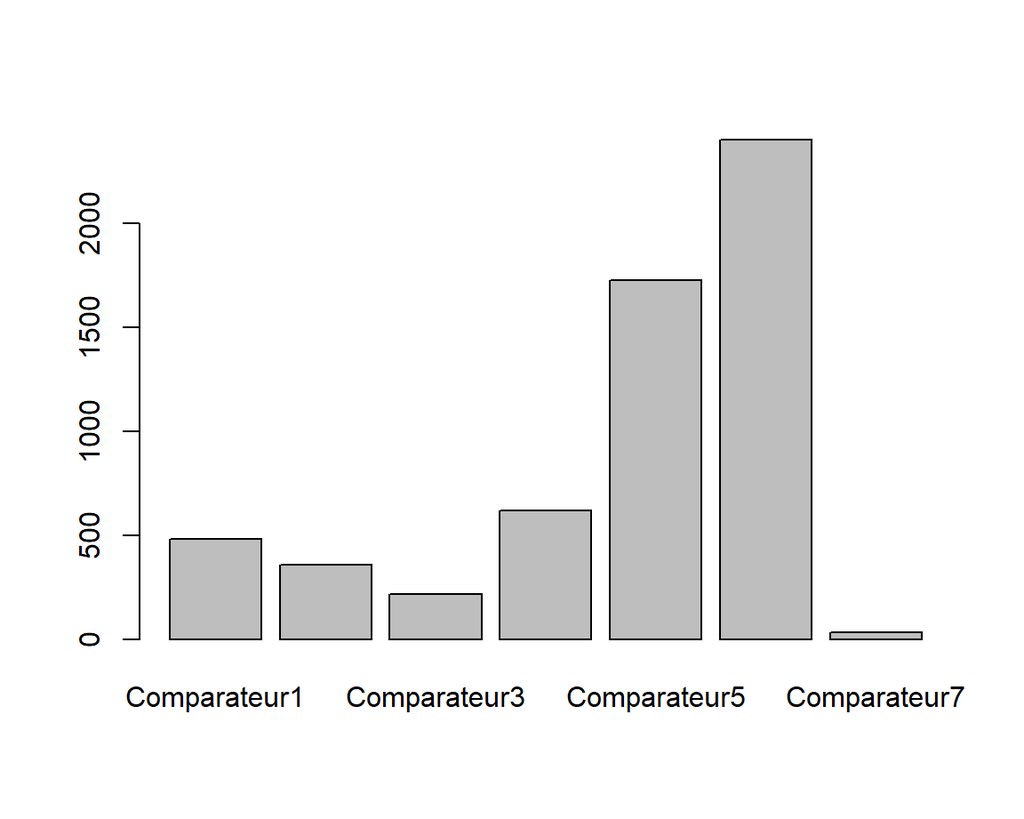

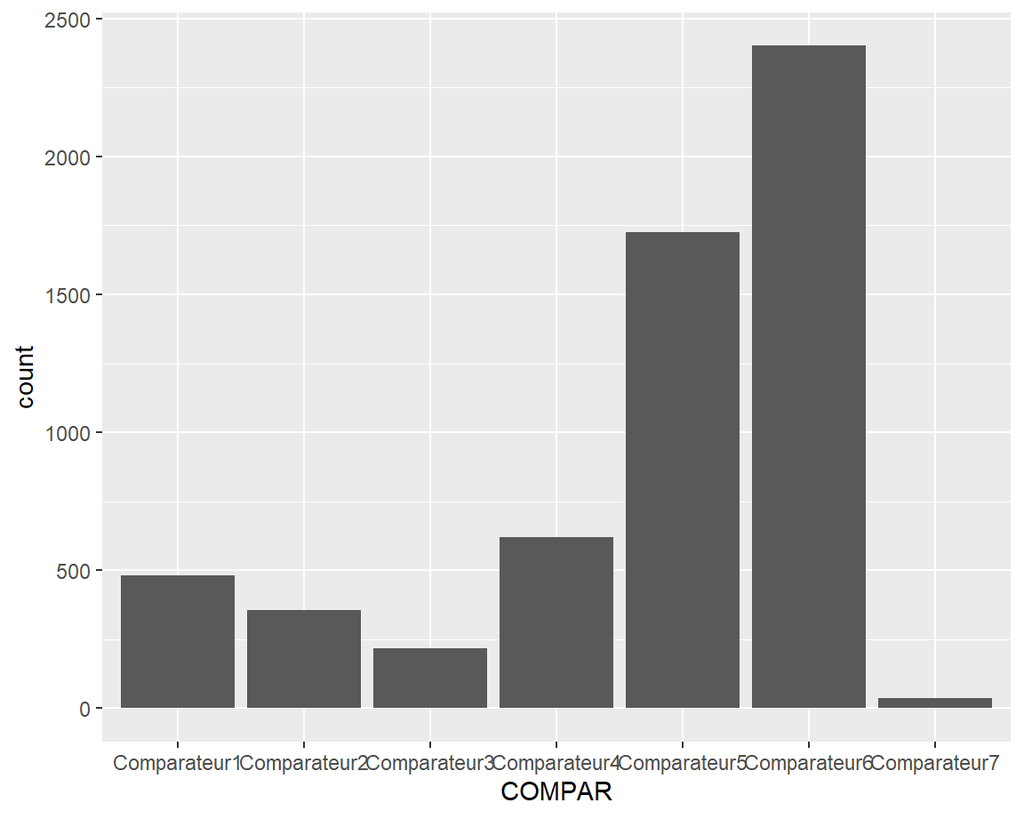

Le comparateur 6 et le comparateur5 sont les plus utilisés. il serait intéressant de vérifier notre rang sur chacun de ses comparateurs.

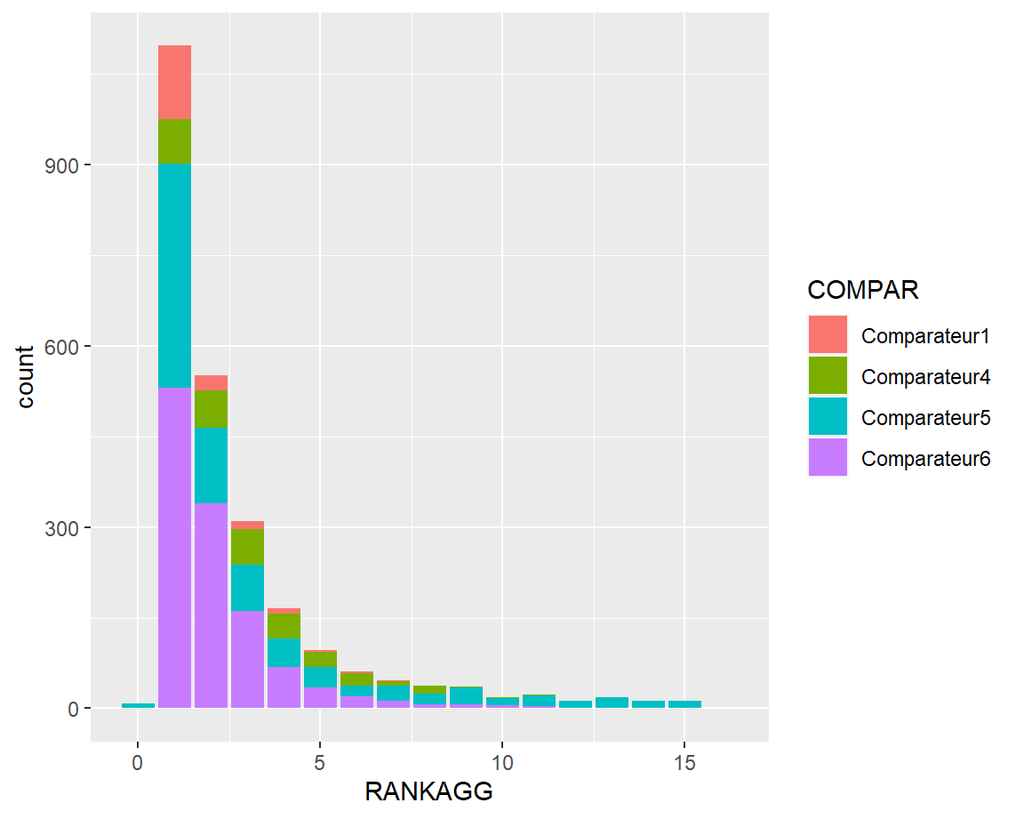

On voit clairement que notre assureur est mieux classé sur les “comparateur6” et “comparateur5” suivi du “comparateur4”. On peut donc conclure que mieux notre assureur est bien classé et plus les assurés souscrivent à nos polices d’assurance.

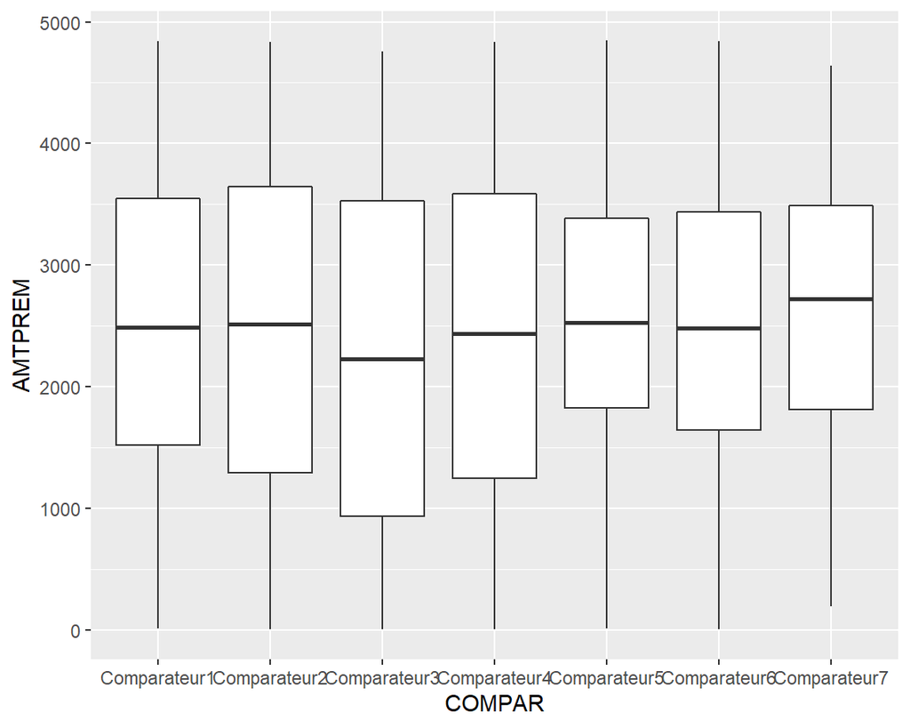

**Conclusion :**On peut donc affirmer que le classement sur le comparateur est d’une importance capitale.

## Analyse des primes en fonction des comparateurs et des différentes formules souscrites

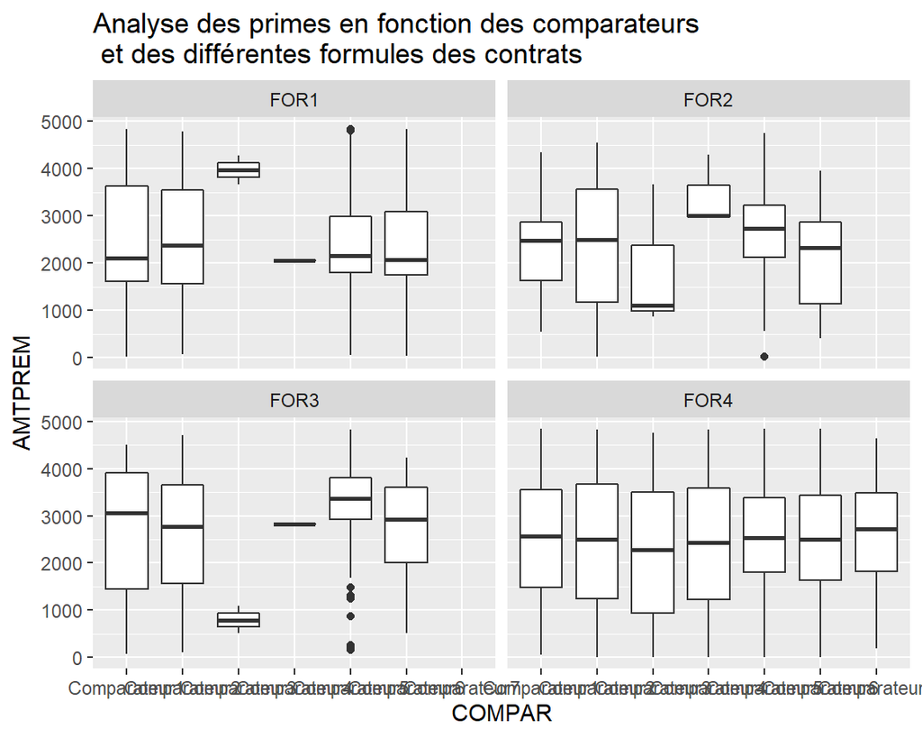

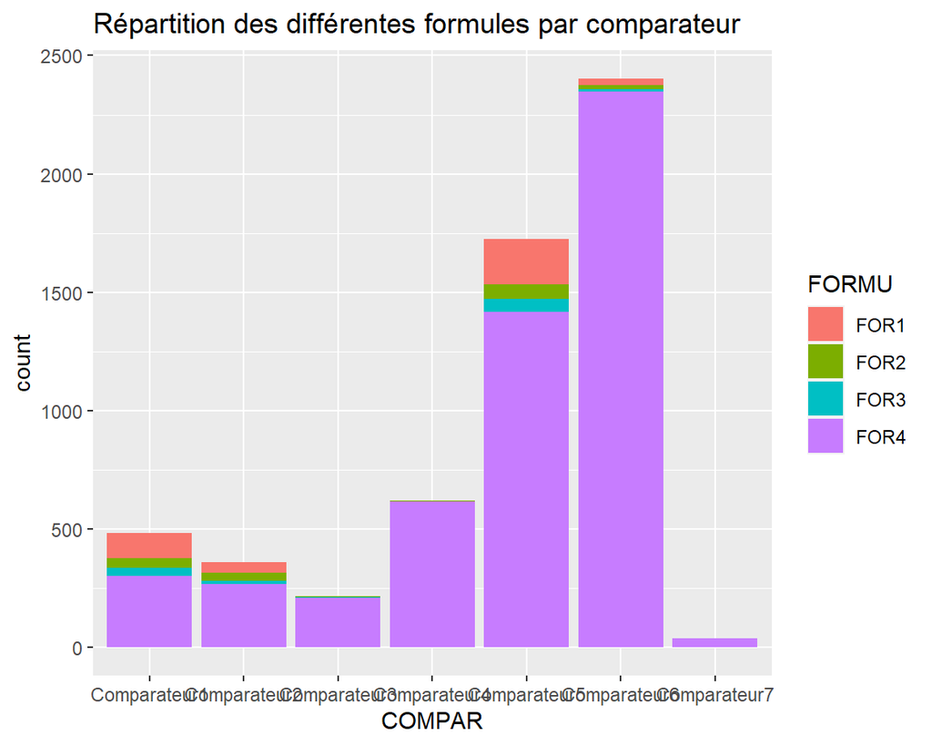

# Analyse

## Analyse des caractéristiques des clients ayant souscrit via les différents comparateurs

###1. la situation professionnelle

```
                  Company head                      Craftsman
                            12                             11
                      Employee                      Executive
                          1876                             95
                     Freelance                          Other
                            24                           1250
Public administration employee                        Retired
                           399                            129
                    Shopkeaper                        Student
                             7                             28
                       Teacher             Without profession
                            62                           1890
                        Worker                           <NA>
                            53                              0
```

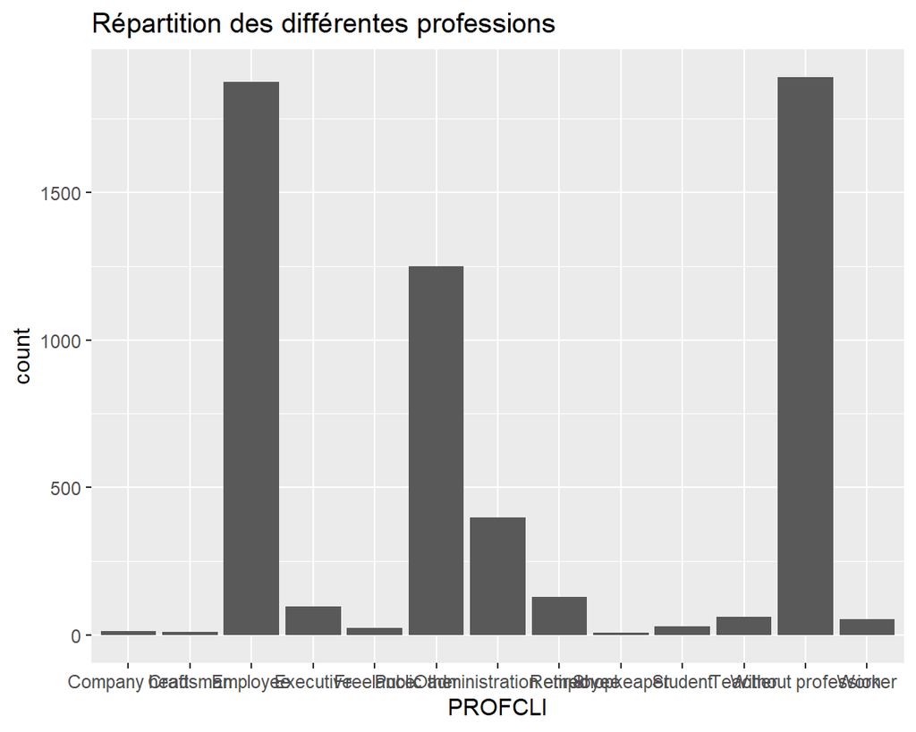

Remarque : Notre base des assurés est constitué majoritairement de personnes sans emploi et d’employés.

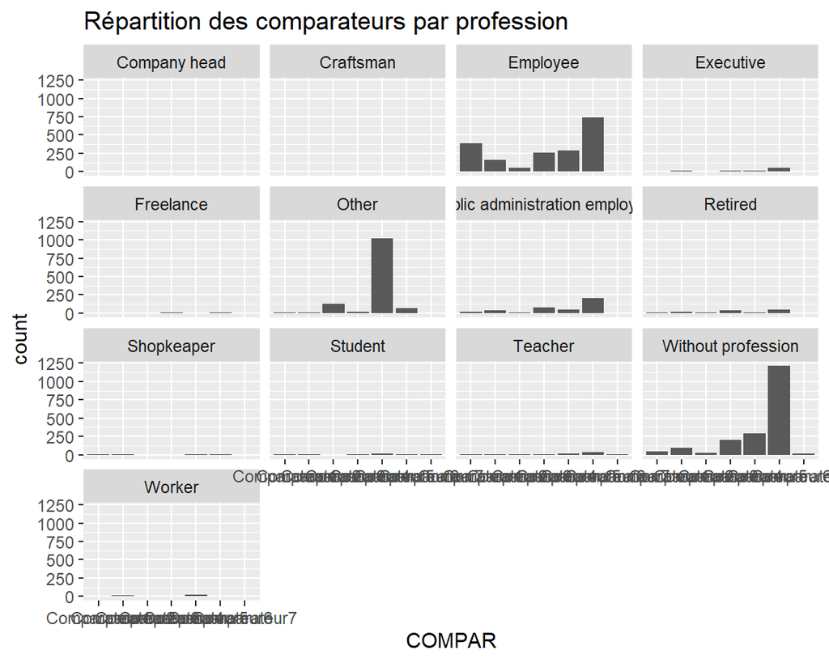

**Interprétation :**